# Graphical data analysis 1

```r
load("out.rData")
library(ggplot2)
```

## SubjectID

One subjectID for each patient

## Mineral balance

**Calcium** routine metabolic panel to assess kidney, bone, or nerve disease. Normal ranges are 2.2-2.5 mmol/L

**Phosphorus** Associated with kidney function, nutritional status, and a variety of chronic illnesses. Normal ranges are 1-1.5 mmol/L.

```r
summary(out$Calcium)
```

```
##    Min. 1st Qu.  Median    Mean 3rd Qu.    Max.    NA's
##   1.747   2.270   2.344   2.343   2.411   4.160     297
```

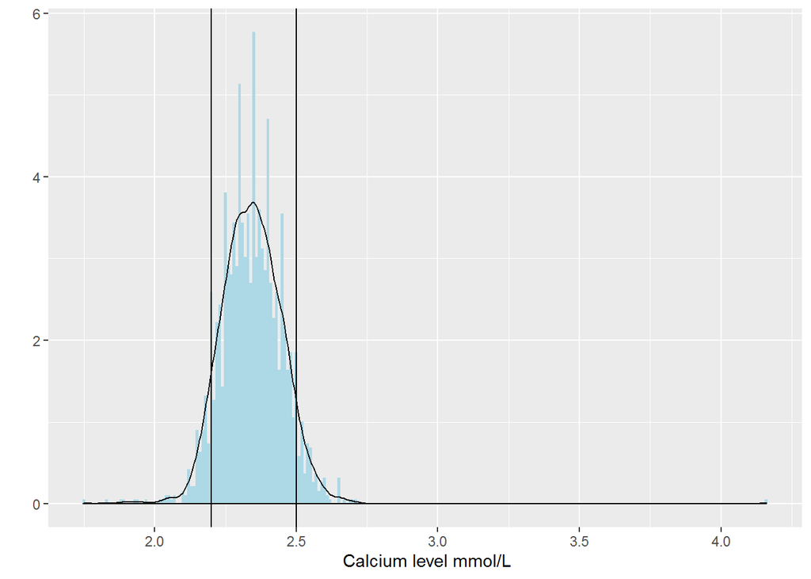

```r
ggplot(na.omit(out), aes(na.omit(out$Calcium))) +
  geom_histogram(aes(y=..density..), binwidth=0.01, fill="lightblue") +
  geom_density() +
  geom_vline(xintercept=c(2.2,2.5)) +
  ylab("") +
  xlab(" Calcium level mmol/L")
```

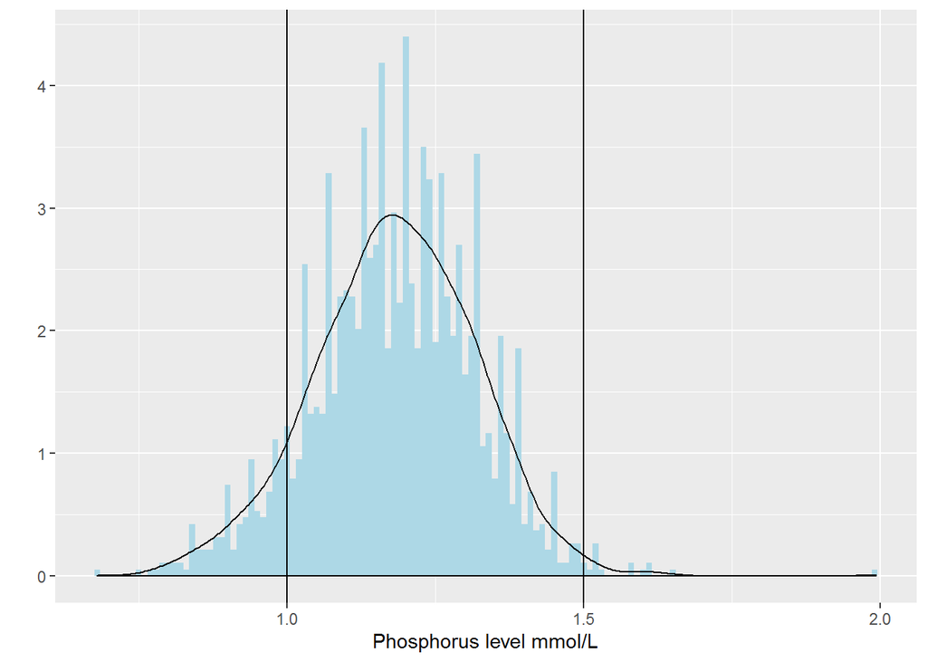

```r
ggplot(na.omit(out), aes(na.omit(out$Phosphorus))) +
  geom_histogram(aes(y=..density..), binwidth=0.01, fill="lightblue") +
  geom_density() +
  geom_vline(xintercept=c(1,1.5)) +
  ylab("") +
  xlab("Phosphorus level mmol/L")
```

## Blood count

**Red Blood Cells (RBC)** A count of the actual number of red blood cells per volume of blood. Both increases and decreases lead to abnormal conditions. Normal ranges are 4.2 - 6.9 $\times 10^9$/L.

[127] “RBC Distribution Width”  
[128] “RBC Morphology”  
[129] “RBC Morphology: Anisocytosis”  
[130] “RBC Morphology: Macrocytosis”  
[131] “RBC Morphology: Microcytosis”  
[132] “RBC Morphology: Spherocytes”  
[133] “Red Blood Cells (RBC)”

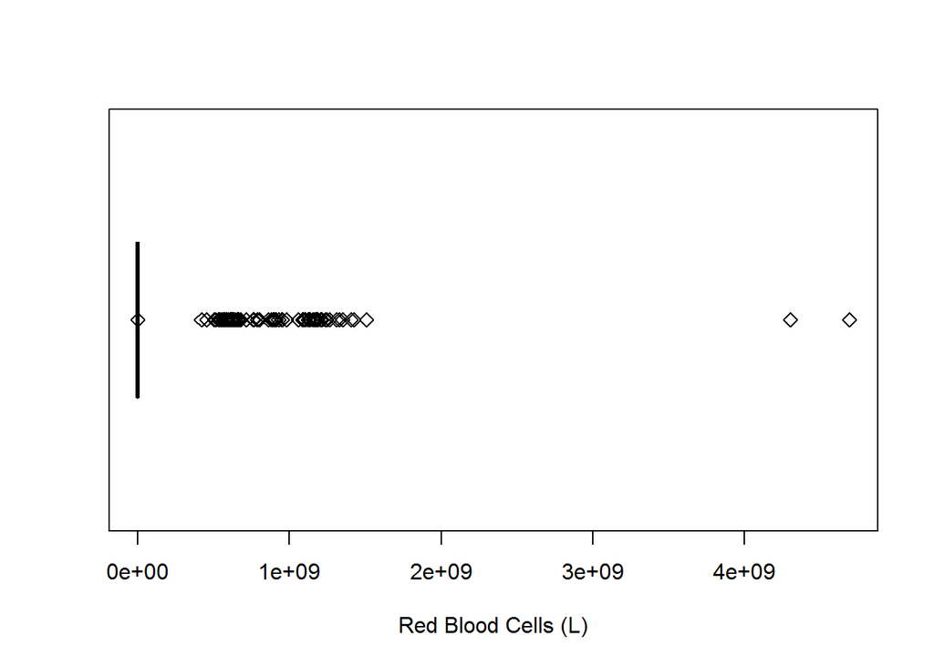

```r
boxplot(out[,133], horizontal=TRUE, pch=5, xlab="Red Blood Cells (L)")
```

Substantially positive skewness is observed. So transformation methods will be applied and selected for further analysis.

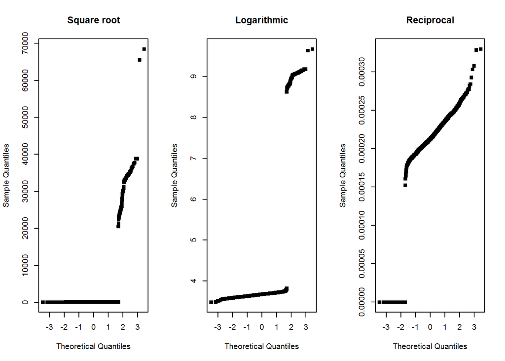

```r
rbc <- out[,133]
trans1 = sqrt(rbc)
trans2 = log10(rbc)
trans3 = 1/rbc

par(mfrow=c(1,3))
qqnorm(trans1, main="Square root", pch=15)
qqnorm(trans2, main="Logarithmic", pch=15)
qqnorm(trans3, main="Reciprocal", pch=15)
```

## ALS Functional Rating Scale (ALSFRS)

The ALSFRS scale is a list of 10 assessments regarding motor function to assess symptom severity, with each measure ranging from 0 to 4, with 4 being the highest (normal function) and 0 being no function. The score for the individual questions are then summed together to generate a number, and that is the ALSFRS score.

In ALSFRS-R, the modified version of ALSFRS, assessment 10 (respiratory function) is further divided into three questions to better reflect the importance (weighting) of respiratory changes within the scale.

[14] “ALSFRS_R _Total"  
[15] “ALSFRS_Total”

[111] “Q1_Speech”  
[112] “Q10_Respiratory”  
[113] “Q2_Salivation”  
[114] “Q3_Swallowing”  
[115] “Q4_Handwriting”  
[116] “Q5_Cutting”  
[117] “Q5a_Cutting *without* Gastrostomy”  
[118] “Q5b_Cutting *with* Gastrostomy”  
[119] “Q6_Dressing *and* Hygiene”  
[120] “Q7_Turning *in* Bed”  
[121] “Q8_Walking”  
[122] “Q9_ Climbing_Stairs”

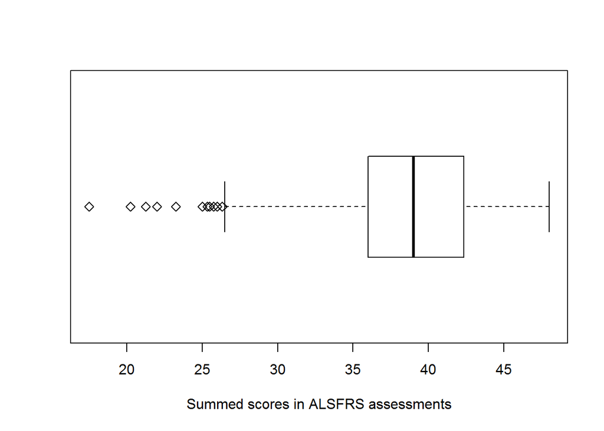

```r
par(mfrow=c(1,1))
boxplot(out[,14], horizontal=TRUE, pch=5, xlab="Summed scores in ALSFRS assessments")
```

ALSFRS score is negatively skewed in a slight manner. So transformation methods will be applied and selected for further analysis.

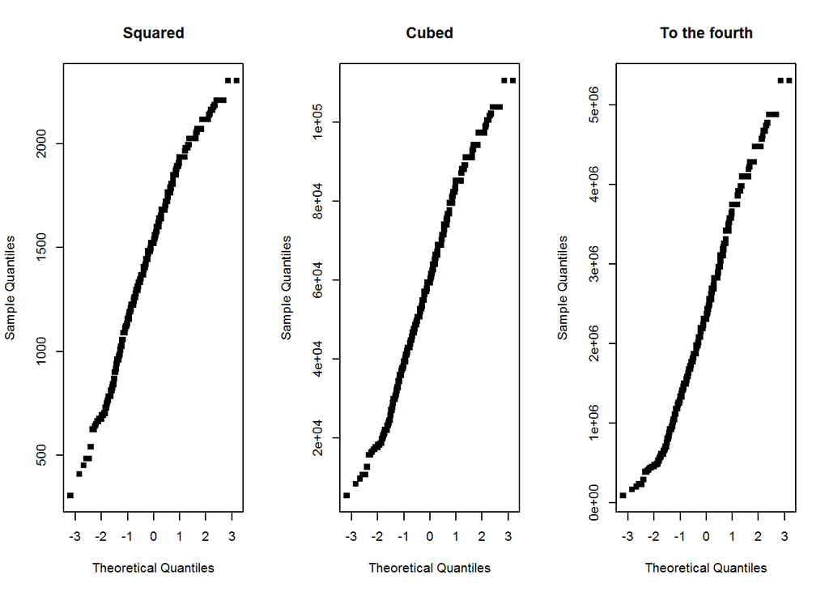

```r
frs <- out[,14]
trans1 = frs^2
trans2 = frs^3
trans3 = frs^4

par(mfrow=c(1,3))
qqnorm(trans1, main="Squared", pch=15)
qqnorm(trans2, main="Cubed", pch=15)
qqnorm(trans3, main="To the fourth", pch=15)
```

## Lung function measures

**Forced vital capacity (FVC)** the volume of air that can forcibly be blown out after full inspiration, measured in liters.

FVC Normal: the expected value for a non-ALS patient (control) matched by gender, age and height)

FVC percent: divide FVC liters by FVC normal

[53] “fvc”  
[54] “fvc_normal”  
[55] “fvc_percent”

**Slow vital capacity** the maximum volume of air that can be exhaled slowly after slow maximum inhalation, measured in liters.

[142] “svc”  
[143] “svc_normal”  
[144] “svc_percent”

```r
summary(out$fvc_percent)
```

```
##    Min. 1st Qu.  Median    Mean 3rd Qu.    Max.    NA's
##   22.72   72.10   82.81   83.00   93.80  149.80     163
```

```r
summary(out$svc_percent)
```

```
##    Min. 1st Qu.  Median    Mean 3rd Qu.    Max.    NA's
##   53.87   75.22   83.98   85.08   93.46  122.40    2025
```

## Treatment group

Some patients received placebo treatments, while others received experimental treatments (medication).

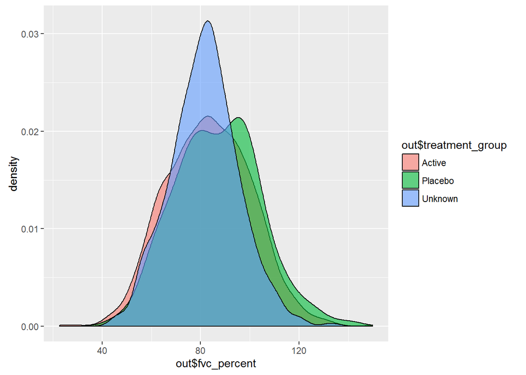

```r
out$treatment_group[is.na(out$treatment_group)] <- "Unknown"
lv <- levels(factor(out$treatment_group))

ggplot(out, aes(out$fvc_percent, fill=out$treatment_group)) +
  geom_density(alpha=.6)
```